# Homework 3: Logistic Regression in R

Supratik Pochampally

This is an R script that will run logistic regression on a data set of acceptance probabilities for Indian graduate school. The original data set was uploaded by Mohan S Archarya, and can be found at https://www.kaggle.com/mohansacharya/graduate-admissions.

### Step 1

```r
# Load the data
df <- read.csv("Admission_Predict.csv")
# Take a look at the first few rows
head(df)
```

|  | Serial.No. | GRE.Score | TOEFL.Score | University.Rating | SOP | LOR | CGPA | Research | Chance.of.Admit |
| --- | --- | --- | --- | --- | --- | --- | --- | --- | --- |
| 1 | 1 | 337 | 118 | 4 | 4.5 | 4.5 | 9.65 | 1 | 0.92 |
| 2 | 2 | 324 | 107 | 4 | 4.0 | 4.5 | 8.87 | 1 | 0.76 |
| 3 | 3 | 316 | 104 | 3 | 3.0 | 3.5 | 8.00 | 1 | 0.72 |
| 4 | 4 | 322 | 110 | 3 | 3.5 | 2.5 | 8.67 | 1 | 0.80 |
| 5 | 5 | 314 | 103 | 2 | 2.0 | 3.0 | 8.21 | 0 | 0.65 |
| 6 | 6 | 330 | 115 | 5 | 4.5 | 3.0 | 9.34 | 1 | 0.90 |

### Step 2

This data set is fairly unbalanced because out of the 400 total students in the data set, 365 have a Chance.of.Admit > 0.5. This means that we have a ratio of 91.25% Chance.of.Admit > 0.5 and 8.75% Chance.of.Admit < 0.5 ratio.

```r
# Make Research a factor
df$Research <- factor(df$Research)
# Get rid of the Serial No column
df <- df[2:9]
# Make a new column that is a binary factor based on if Chance.of.Admit > 0.5
df$Admit <- factor(ifelse(df$Chance.of.Admit > 0.5, 1, 0))
# Output column names
names(df)
```

```
## [1] "GRE.Score"         "TOEFL.Score"       "University.Rating"
## [4] "SOP"               "LOR"               "CGPA"
## [7] "Research"          "Chance.of.Admit"   "Admit"
```

```r
# Output summary
summary(df)
```

```
##    GRE.Score      TOEFL.Score    University.Rating      SOP
##  Min.   :290.0   Min.   : 92.0   Min.   :1.000     Min.   :1.0
##  1st Qu.:308.0   1st Qu.:103.0   1st Qu.:2.000     1st Qu.:2.5
##  Median :317.0   Median :107.0   Median :3.000     Median :3.5
##  Mean   :316.8   Mean   :107.4   Mean   :3.087     Mean   :3.4
##  3rd Qu.:325.0   3rd Qu.:112.0   3rd Qu.:4.000     3rd Qu.:4.0
##  Max.   :340.0   Max.   :120.0   Max.   :5.000     Max.   :5.0
##       LOR             CGPA       Research Chance.of.Admit  Admit
##  Min.   :1.000   Min.   :6.800   0:181    Min.   :0.3400   0: 35
##  1st Qu.:3.000   1st Qu.:8.170   1:219    1st Qu.:0.6400   1:365
##  Median :3.500   Median :8.610            Median :0.7300
##  Mean   :3.453   Mean   :8.599            Mean   :0.7244
##  3rd Qu.:4.000   3rd Qu.:9.062            3rd Qu.:0.8300
##  Max.   :5.000   Max.   :9.920            Max.   :0.9700
```

### Step 3

The graphs below show that both high GRE scores and high TOEFL scores have a strong correlation with Admits, and that they are both good predictors.

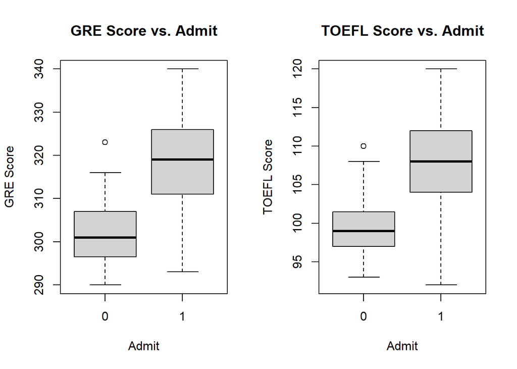

```r
# Create side by side graphs
par(mfrow=c(1, 2))
# GRE vs. Admit
plot(df$Admit, df$GRE.Score, main="GRE Score vs. Admit", xlab="Admit", ylab="GRE Score")
plot(df$Admit, df$TOEFL.Score, main="TOEFL Score vs. Admit", xlab="Admit", ylab="TOEFL Score")
```

### Step 4

```r
# Use seed to guarantee same split every run
set.seed(1234)
# Divide into train/test data
i <- sample(1:nrow(df), 0.75*nrow(df), replace=FALSE)
train <- df[i, ]
test <- df[-i, ]
```

### Step 5

The following warnings occurred:

Warning: glm.fit: algorithm did not converge

Warning: glm.fit: fitted probabilities numerically 0 or 1 occurred

```r
# Build a model predicting Admit from all predictors
glm0 <- glm(Admit~., data=train, family=binomial)
```

```
## Warning: glm.fit: algorithm did not converge
```

```
## Warning: glm.fit: fitted probabilities numerically 0 or 1 occurred
```

### Step 6

```r
# Build a model predicting Admit from all predictors excluding Chance.of.Admit
glm1 <- glm(Admit~.-Chance.of.Admit, data=train, family=binomial)
```

### Step 7

Looking at some of the probabilities and test predictions, we can conclude that the model was able to differentiate between low probabilities (44% and 8%) and higher probabilities.

```r
# Calculate the probabilities and display a few
probs <- predict(glm1, newdata=test, type="response")
# Display few probabilities and test probs
tail(df$Chance.of.Admit, n=10)
```

```
##  [1] 0.64 0.71 0.84 0.77 0.89 0.82 0.84 0.91 0.67 0.95
```

```r
tail(probs, n=10)
```

```
##        369        377        383        386        387        390        392
## 0.43978784 0.08159202 0.99891453 0.99998354 0.92139338 0.99392239 0.99570082
##        396        397        400
## 0.99930046 0.99941742 0.99994405
```

```r
# Calculate the correlation between the predicted probabilities and Chance.of.Admit
cor(probs, test$Chance.of.Admit)
```

```
## [1] 0.648545
```

### Step 8

```r
# Calculate the predicted probabilities and display a few
pred <- ifelse(probs > 0.5, 1, 0)
# Make binary predictions and output a table
table(pred, test$Admit)
```

```
##
## pred  0  1
##    0  5  2
##    1  4 89
```

```r
# Calculate and output the accuracy
acc1 <- mean(pred==test$Admit)
print(paste("glm1 accuracy = ", acc1))
```

```
## [1] "glm1 accuracy =  0.94"
```

### Step 9

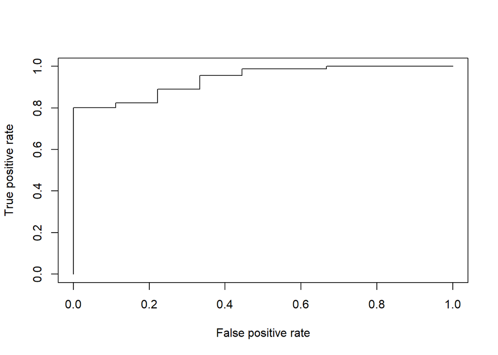

```r
# Include the library ROCR
library(ROCR)
# Calculate the predictions for the ROCR graph
p <- predict(glm1, newdata=test, type="response")
pr <- prediction(p, test$Admit)
# Use the TPR measure for sensitivity and FPR measure for specificity
prf <- performance(pr, measure = "tpr", x.measure = "fpr")
# Plot the ROCR graph
plot(prf)
```

```r
# Calculate and print the AUC based on performance
auc <- performance(pr, measure = "auc")
auc <- auc@y.values[[1]]
print(paste("glm1 auc = ", auc))
```

```
## [1] "glm1 auc =  0.938949938949939"
```

### Step 10

Both of the graphs show that both Admit and Research have an impact on the statement of purpose of each student.

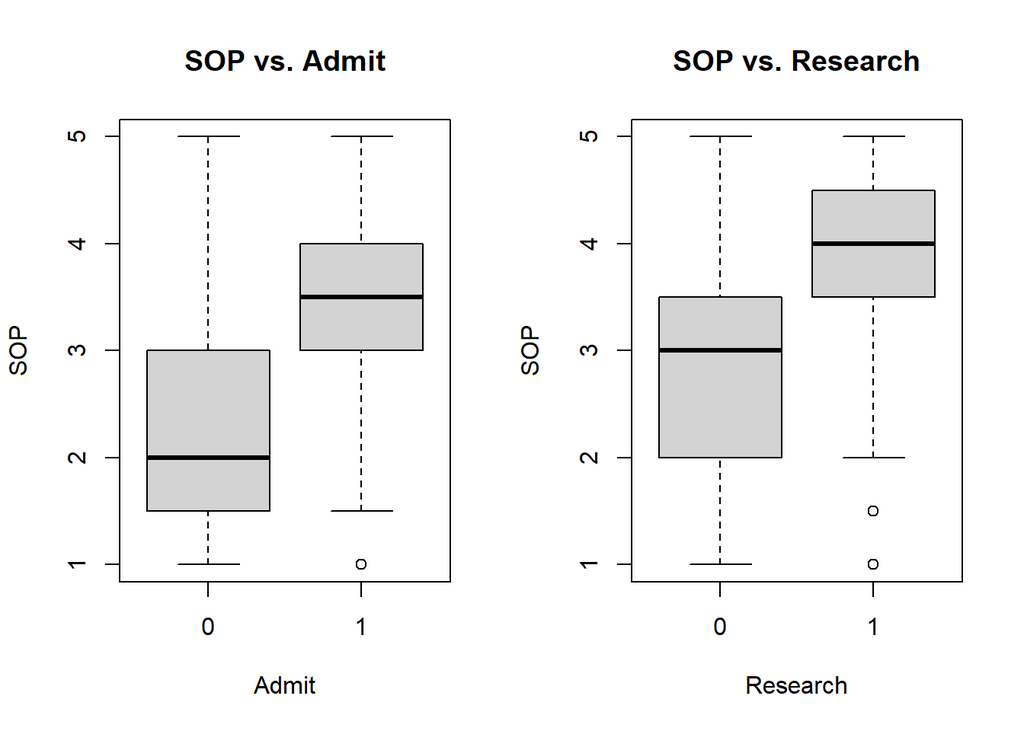

```r
# Create side by side graphs
par(mfrow=c(1, 2))
# SOP vs. Admit
plot(df$Admit, df$SOP, main="SOP vs. Admit", xlab="Admit", ylab="SOP")
# SOP vs. Research
plot(df$Research, df$SOP, main="SOP vs. Research", xlab="Research", ylab="SOP")
```